# HWL10

Daniel Briseno Servin

12/2/2020

## Question 1

First we run a simple visualization to get an intuition about the distribution of outliers

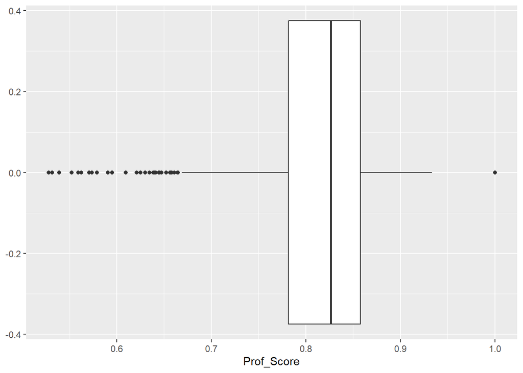

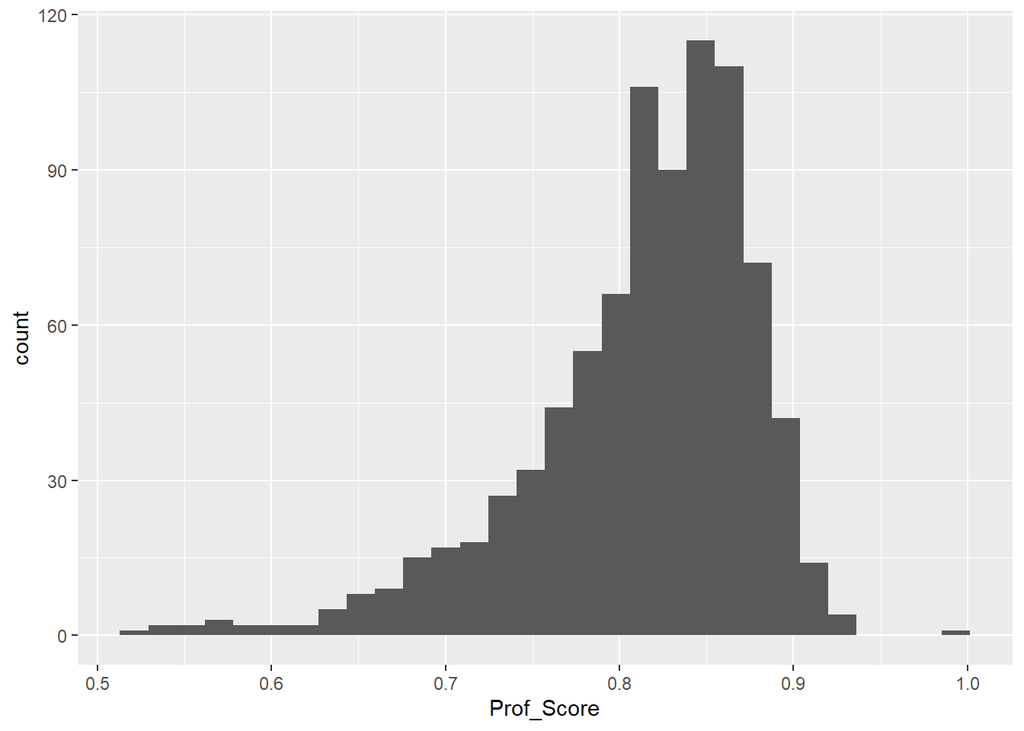

Both the Histogram and the Boxplot tell a similar story.

There is one value which can be considered unusally high, with a value of ~1. This datapoint might be safely considered an outlier.

There is a larger amount of unusually low values. Additionally, these low values are often clustered together (close in value). These low values might indicate a trend in the data which should not be left out of the analysis. However, the number of low outliers is still small when compared to the rest of the data.

Selecting outliers based off of Rosner’s test, +/- IQR, and +/- 3SDs gives the following:

- Rosner’s Test

```
## $distribution
## [1] "Normal"
##
## $statistic
##      R.1      R.2      R.3      R.4      R.5      R.6      R.7      R.8
## 4.338596 4.330805 4.267638 4.104143 4.041012 4.027859 3.938342 3.926427
##      R.9     R.10     R.11     R.12     R.13     R.14     R.15     R.16
## 3.878204 3.724221 3.677625 3.469235 3.301041 3.257184 3.194082 3.151535
##     R.17     R.18     R.19     R.20
## 3.153052 3.095109 3.095218 3.094104
##
## $sample.size
## [1] 864
##
## $parameters
```

[output cut: 180 more lines]

- +/-3SDs:

```
## $Prof_Score
## $Prof_Score$idx
##  [1] 126 148 150 377 388 399 421 483 584 593 727 798
##
## $Prof_Score$val
##  [1] 0.5315789 0.5523810 0.5388889 0.5590909 0.6095238 0.5625000 0.5277778
##  [8] 0.5705882 0.5736842 0.5952381 0.5789474 0.5904762
##
## $Prof_Score$count
## [1] 12
##
## $Prof_Score$mu
## [1] 0.812704
##
## $Prof_Score$thres_l
## [1] 0.6156867
##
## $Prof_Score$thres_u
## [1] 1.009721
```

- +/-IQR:

```
## $Prof_Score
## $Prof_Score$idx
##  [1]  79 103 126 132 148 150 168 214 232 248 262 273 331 377 388 399 421 462 483
## [20] 485 494 513 521 581 584 593 596 659 682 727 798 855
##
## $Prof_Score$val
##  [1] 0.6343750 1.0000000 0.5315789 0.6400000 0.5523810 0.5388889 0.6578947
##  [8] 0.6523810 0.6611111 0.6388889 0.6250000 0.6300000 0.6210526 0.5590909
## [15] 0.6095238 0.5625000 0.5277778 0.6454545 0.5705882 0.6411765 0.6642857
## [22] 0.6611111 0.6647059 0.6578947 0.5736842 0.5952381 0.6450000 0.6444444
## [29] 0.6562500 0.5789474 0.5904762 0.6473684
##
## $Prof_Score$mu
## [1] 0.812704
##
## $Prof_Score$count
## [1] 32
##
## $Prof_Score$thres_l
##       25%
## 0.6673482
##
## $Prof_Score$thres_u
##       75%
## 0.9722226
```

Using Rosner’s test for outliers, 6 points are labeled as outliers. All of the outliers are extremely low values, and the one high outlier seen in the visualization is kept. Excluding less low outliers from consideration might be good, since there is a cluster of low datapoints which might be informative if left in the analysis.

Using +/- 3SDs, we exclude 12 low datapoints from the analysis.

Using +/- IQR, we do exclude the large value of 1.00, but at the cost of exuding all of the low datapoints.

Based off of these observations, I believe that the best approach is to use Rosner’s test in order to keep most of the low outliers. Depending on whether the high outlier is likely due to error or a true measured value, it might be best to manually remove it from consideration.

## 2

First we use summary statistics to determine for which variables NA appear:

```
##      Gender         Adult          Face_Angle      Image_Color   Image_Quality
##  female :2300   Min.   :0.0000   Min.   :0.0000   Min.   :0.00   fair:3137
##  male   :6402   1st Qu.:1.0000   1st Qu.:0.0000   1st Qu.:0.00   good:4852
##  unknown:  85   Median :1.0000   Median :1.0000   Median :0.00   NA's: 798
##                 Mean   :0.9332   Mean   :0.7165   Mean   :0.44
##                 3rd Qu.:1.0000   3rd Qu.:1.0000   3rd Qu.:1.00
##                 Max.   :1.0000   Max.   :1.0000   Max.   :1.00
##
##    Image_Type        Context       Multiface                   Race
##  Min.   :0.0000   ad     :2639   Min.   :0.0000   americanindian :  71
##  1st Qu.:1.0000   author : 185   1st Qu.:0.0000   asian          : 413
##  Median :1.0000   cover  : 353   Median :1.0000   black          : 593
##  Mean   :0.8676   feature:5610   Mean   :0.5542   pacificislander:  74
##  3rd Qu.:1.0000                  3rd Qu.:1.0000   unknown        : 155
##  Max.   :1.0000                  Max.   :1.0000   white          :7481
##
##      Smile             Area
##  Min.   :0.0000   Min.   :    594
##  1st Qu.:0.0000   1st Qu.:   8100
##  Median :0.0000   Median :  14140
##  Mean   :0.4367   Mean   :  35250
##  3rd Qu.:1.0000   3rd Qu.:  31465
##  Max.   :1.0000   Max.   :1576872
##  NA's   :2875
```

Summary statistics determine that we have missing variables in Image_Quality and Smile.

Next we use a random forest algorithm to determine if missing values are MAR or MCAR:

```
## [1] "IQ_Miss:"
```

```
## [1] 0.08933652
```

```
##
##          0          1
## 0.90918402 0.09081598
```

```
## [1] "Smile_Miss:"
```

```
## [1] 0.3313987
```

```
##
##         0         1
## 0.6728121 0.3271879
```

For both Image_Quality and Smile, we see that the the error rate and the NA rate is almost the same. Thus, we can conclude that Image_Quality and Smile are likely MCAR.

Next we run a linear regression model predicting area by removing NA listwise.

```
##
## Call:
## glm(formula = Area ~ Gender + Adult + Face_Angle + Image_Color +
##     Image_Quality + Image_Type + Context + Multiface + Race +
##     Smile, data = df_del)
##
## Deviance Residuals:
##     Min       1Q   Median       3Q      Max
## -153151   -25364    -9754     8395  1443587
##
## Coefficients:
##                     Estimate Std. Error t value Pr(>|t|)
## (Intercept)            43769      12857   3.404 0.000668 ***
## Gendermale              7090       2448   2.896 0.003790 **
## Genderunknown          57567      10593   5.435 5.74e-08 ***
## Adult                  -4571       4463  -1.024 0.305859
## Face_Angle              1131       2373   0.476 0.633767
## Image_Color             3471       2142   1.621 0.105144
## Image_Qualitygood      24091       2186  11.018  < 2e-16 ***
## Image_Type              6051       3415   1.772 0.076460 .
## Contextauthor         -23080       9813  -2.352 0.018706 *
## Contextcover           68235       5370  12.706  < 2e-16 ***
## Contextfeature        -16050       2663  -6.026 1.79e-09 ***
## Multiface             -25740       2169 -11.867  < 2e-16 ***
## Raceasian              -4762      12134  -0.392 0.694735
## Raceblack             -10334      11869  -0.871 0.383943
## Racepacificislander   -11449      16079  -0.712 0.476464
## Raceunknown             7345      13836   0.531 0.595534
## Racewhite              -8860      11234  -0.789 0.430366
## Smile                  -4582       2204  -2.079 0.037630 *
## ---
## Signif. codes:  0 '***' 0.001 '**' 0.01 '*' 0.05 '.' 0.1 ' ' 1
##
## (Dispersion parameter for gaussian family taken to be 5856141474)
##
##     Null deviance: 3.5574e+13  on 5390  degrees of freedom
## Residual deviance: 3.1465e+13  on 5373  degrees of freedom
## AIC: 136567
##
## Number of Fisher Scoring iterations: 2
```

We repeat the same process but with multiple imputation:

```
##                   term    estimate std.error    statistic         df
## 1          (Intercept)  27672.5131 10399.942   2.66083332 8323.66894
## 2           Gendermale   7330.1322  1952.573   3.75408903 3170.21955
## 3        Genderunknown  68956.8915  8768.397   7.86425289 8064.19422
## 4                Adult   1300.5768  3388.162   0.38385910 8541.93066
## 5           Face_Angle   1209.0655  1857.972   0.65074462 8737.00906
## 6          Image_Color   5769.1645  1691.798   3.41007932 8678.89661
## 7    Image_Qualitygood  24264.5386  1745.772  13.89902899 3680.77790
## 8           Image_Type   8971.9028  2596.506   3.45537538 8257.93098
## 9        Contextauthor -23475.5900  5963.782  -3.93635932 7070.76052
## 10        Contextcover  54583.3869  4429.887  12.32162050 8016.50449
## 11      Contextfeature -18940.0576  1996.040  -9.48881830 3537.27646
## 12           Multiface -24159.4270  1715.697 -14.08140416 7949.23218
## 13           Raceasian   4438.1195  9911.023   0.44779633 8415.41423
## 14           Raceblack  -3548.8121  9687.703  -0.36632130 8321.06169
```

[output cut: 23 more lines]